# Citibike Trips

Gabrielle Martinez (Pace University)

6/17/2020

## Load Dataset

Load in the `trips_per_day.tsv` which has one row for each day, the number of trips taken on that day, and the some weather data for the day. `holiday.csv` is a data set with the US bank holidays between 2012 and 2020.

```r
trips_per_day <- read_tsv("trips_per_day.tsv")
#trips_per_day <- read_tsv(here("trips_per_day.tsv"))

holiday <- read.csv("holidays.csv", header = F, col.names = c('num', 'date', 'holiday'))

#clean and format

holiday %>%
  mutate(date = as.Date(date)) %>%
  select(date,holiday)-> holiday

left_join(trips_per_day, holiday, by = c("ymd"="date")) -> trips_per_day

trips_per_day %>%
  mutate(israining = prcp >= 0.1) %>%
  mutate(day_of_week = as.factor(wday(ymd))) %>%
  mutate(isweekday = day_of_week != 1 & day_of_week != 7) %>%
  mutate(isholiday = ifelse(!is.na(holiday), 1, 0)) -> trips_per_day

#trips_per_day %>%
#  mutate(month = )
#  mutate(season = ifelse(, x, y))

####
```

trips_per_day has 365 observations

## Split the data

Split the data into into testing (10%), validation (10%), and training sets (80%).

```r
set.seed(43)

num_obs = nrow(trips_per_day)
train_frac = 0.8
val_frac = 0.1

num_train <- floor(num_obs * train_frac)
num_validate <- floor(num_obs*val_frac)


# randomly sample rows for the training set
ndx <- sample(1:num_obs, num_train, replace=F)

#training set 80%
train_trips_per_day <- trips_per_day[ndx, ]

#20%
split20 <- trips_per_day[-ndx, ]

ndx <- sample(1:73, num_validate, replace=F)

#validation set 10%
val_trips <- split20[ndx, ]

#testing set 10%
test_trips <- split20[-ndx, ]
```

Training set has 292 obs. Validation set has 36 obs. Testing set has 37 obs. Testing set is not to be touched until the very end.

## Model 1: Minimum Temperature

Can we predict the number to trips in a day using solely the minimum temperature?

Test different polynomial degrees

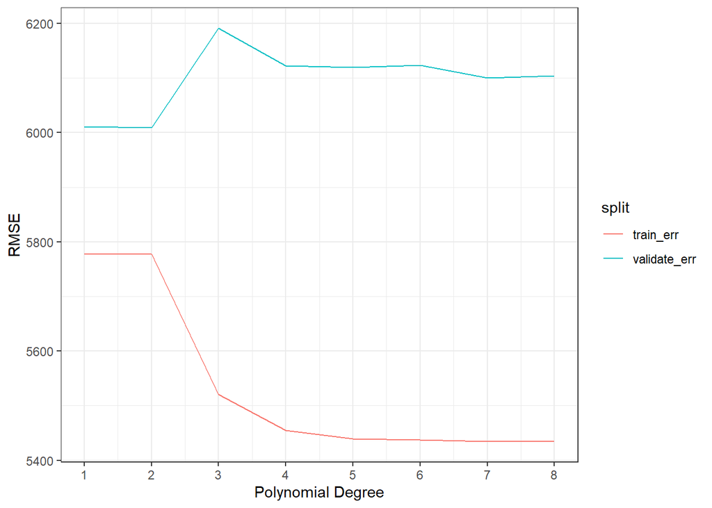

```r
# fit a model for each polynomial degree
K <- 1:8
train_err <- c()
validate_err <- c()
for (k in K) {

    # fit on the training data
    model1 <- lm(num_trips ~ poly(tmin, k, raw = T), data = train_trips_per_day)

    #num_trips = tmin + tmin^2 + ... + tmin^k

    # RMSE training data
    train_err[k] <- sqrt(mean((predict(model1, train_trips_per_day) - train_trips_per_day$num_trips)^2))

    # RMSE validation data
    validate_err[k] <- sqrt(mean((predict(model1, val_trips) - val_trips$num_trips)^2))
}

#plot RMSE

plot_data <- data.frame(K, train_err, validate_err) %>%
  gather("split", "error", -K)
  #pivot_longer(c(-K),"split", "error")

ggplot(plot_data, aes(x=K, y=error, color=split)) +
  geom_line() +
  scale_x_continuous(breaks=K) +
  xlab('Polynomial Degree') +
  ylab('RMSE')
```

For model 1, the 2nd degree seems to have the smallest gap between the training and vailidation errors. At the 2nd polynomial degreee, the training RMSE is 5777.2075238 and the validation RMSE is 6009.2877449. However, I’ll be using the 3rd degree because it seems to fit the data better, as seen below.

```r
model1 <- lm(num_trips ~ poly(tmin, 3, raw = T),train_trips_per_day)

tidy(model1)
```

```
## # A tibble: 4 x 5
##   term                    estimate std.error statistic     p.value
##   <chr>                      <dbl>     <dbl>     <dbl>       <dbl>
## 1 (Intercept)               13950.    3464.       4.03 0.0000722
## 2 poly(tmin, 3, raw = T)1   -9528.    2907.      -3.28 0.00117
## 3 poly(tmin, 3, raw = T)2    3852.     743.       5.18 0.000000412
## 4 poly(tmin, 3, raw = T)3    -304.      58.1     -5.23 0.000000320
```

```r
glance(model1)
```

```
## # A tibble: 1 x 11
##   r.squared adj.r.squared sigma statistic  p.value    df logLik   AIC   BIC
##       <dbl>         <dbl> <dbl>     <dbl>    <dbl> <int>  <dbl> <dbl> <dbl>
## 1     0.706         0.703 5559.      231. 2.80e-76     4 -2930. 5871. 5889.
## # ... with 2 more variables: deviance <dbl>, df.residual <int>
```

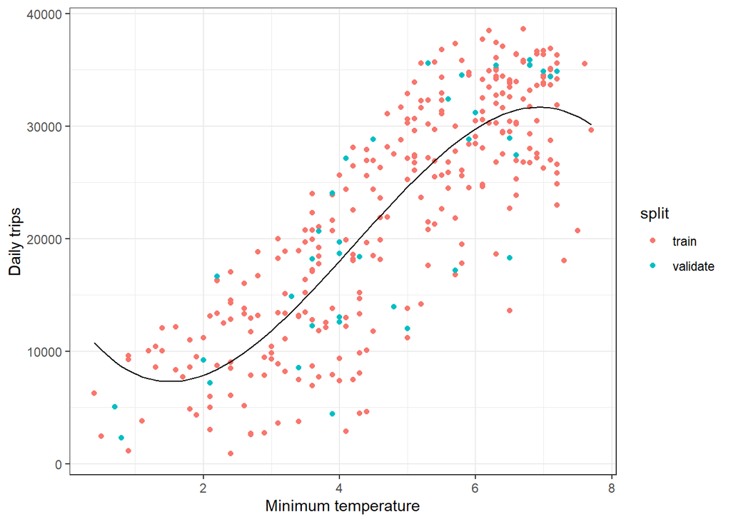

```r
train_trips_per_day <- train_trips_per_day %>%
  add_predictions(model1) %>%
  mutate(split = "train")

val_trips <- val_trips %>%
  add_predictions(model1) %>%
  mutate(split = "validate")

plot_data <- bind_rows(train_trips_per_day, val_trips)

ggplot(plot_data, aes(x = tmin, y = num_trips)) +
  geom_point(aes(color = split)) +
  geom_line(aes(y = pred)) +
  xlab('Minimum temperature') +
  ylab('Daily trips')
```

## Model 2: Minimum Temperature and Preciptation

```r
model2 <- lm(num_trips ~ tmin + prcp, train_trips_per_day)

tidy(model2)
```

```
## # A tibble: 3 x 5
##   term        estimate std.error statistic  p.value
##   <chr>          <dbl>     <dbl>     <dbl>    <dbl>
## 1 (Intercept)     215.      883.     0.244 8.07e- 1
## 2 tmin           4813.      172.    27.9   5.12e-84
## 3 prcp          -6007.      660.    -9.10  1.50e-17
```

```r
glance(model2)
```

```
## # A tibble: 1 x 11
##   r.squared adj.r.squared sigma statistic  p.value    df logLik   AIC   BIC
##       <dbl>         <dbl> <dbl>     <dbl>    <dbl> <int>  <dbl> <dbl> <dbl>
## 1     0.750         0.748 5120.      433. 1.02e-87     3 -2907. 5821. 5836.
## # ... with 2 more variables: deviance <dbl>, df.residual <int>
```

R^2 is 0.75 which means that this model explains 75% of the variation in the number of trips per day

```r
train_trips_per_day %>%
  add_predictions(model2) %>%
  mutate(split = "train") -> plot_data

#RMSE - training set
train_rmse <- sqrt(mean((plot_data$pred - plot_data$num_trips)^2))


val_trips %>%
  add_predictions(model2) %>%
  mutate(split="validation") -> val_trips_data

#RMSE = sqrt(mean((yhat-y)^2)) -> validation set
validate_rmse <- sqrt(mean((val_trips_data$pred - val_trips_data$num_trips)^2))
```

The RMSE is the square root of the average of squared differences between the number of trips predicted and the number of trips actually taken.

The RMSE for the training set is 5093.2307972 trips. For the validation set, RMSE = 4686.6836762 trips.

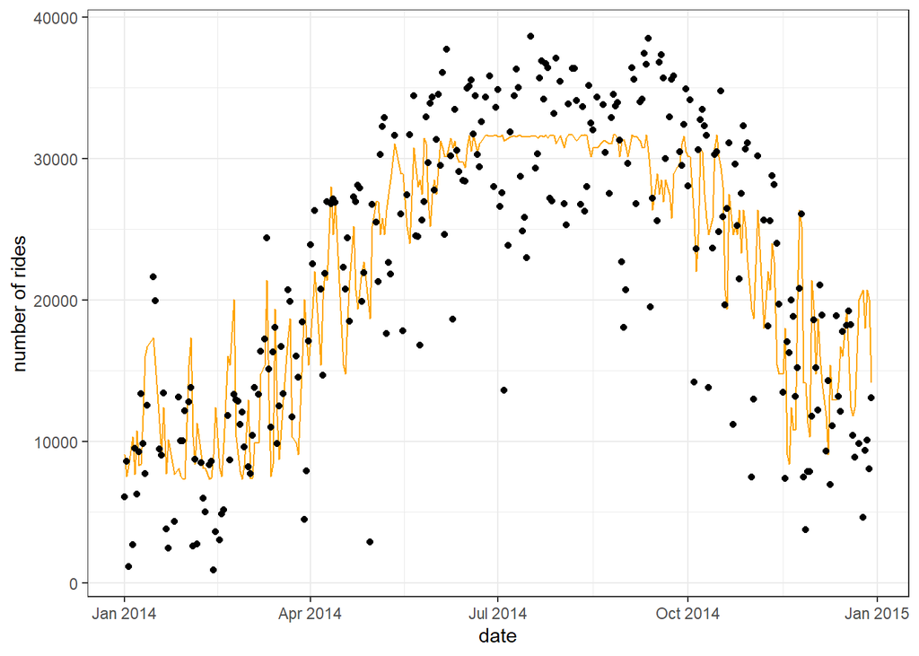

```r
plot_data <- bind_rows(train_trips_per_day, val_trips)

ggplot(train_trips_per_day, aes(x= ymd, y=pred)) +
  geom_line(aes(y=pred), color = "orange") +
  geom_point(aes(y=num_trips)) +
  ylab("number of rides") +
  xlab("date")
```

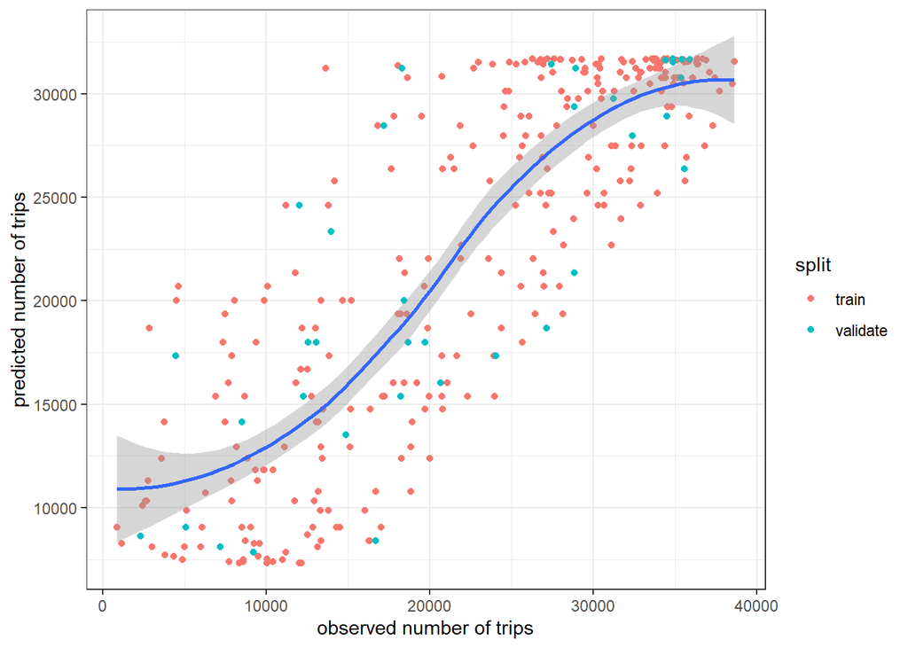

```r
ggplot(plot_data, aes(x=num_trips, y=pred)) +
  geom_point(aes(color=split)) +
  geom_smooth()+
  xlab("observed number of trips")+
  ylab("predicted number of trips")
```

> There are some outliers in the precipitation data that should be accounted for in later itterations.

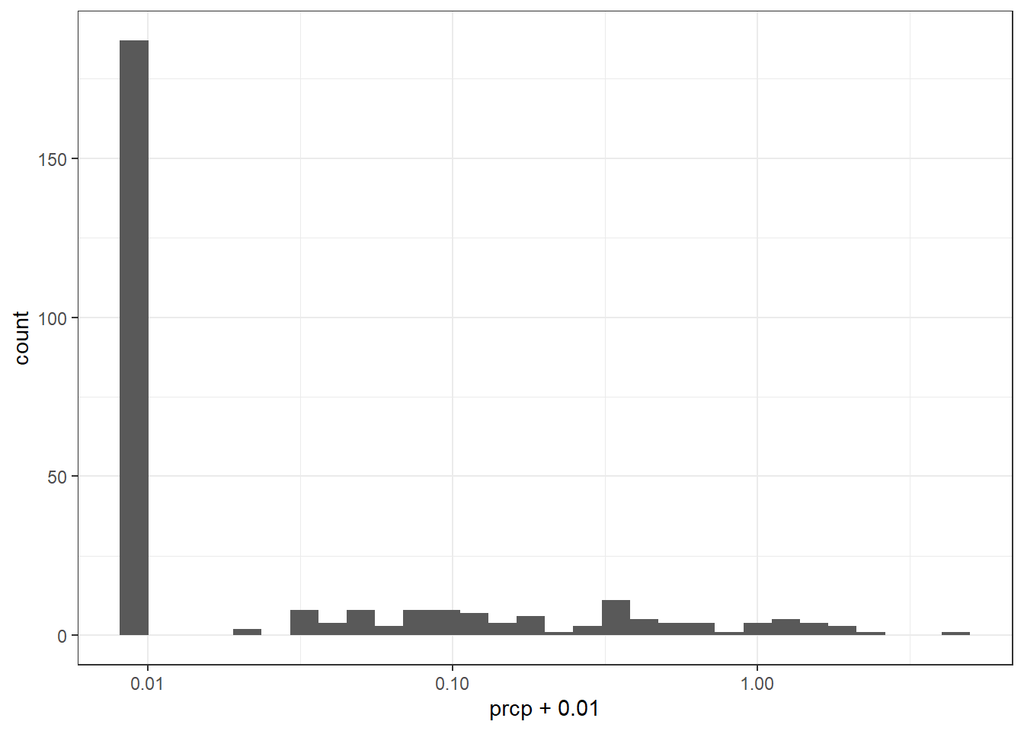

```r
train_trips_per_day %>%
  ggplot(aes(x=prcp+.01)) +
  geom_histogram() +
  scale_x_log10()
```

> Most of the data is concentrated at 0. Make use of the israining variable.

## Experiment

The following will be a series of experimenting with models to improve upon model 2

```r
model3 <- lm(num_trips ~ poly(tmin, 3, raw=T) + israining*isweekday, train_trips_per_day)

tidy(model3)
```

```
## # A tibble: 7 x 5
##   term                        estimate std.error statistic  p.value
##   <chr>                          <dbl>     <dbl>     <dbl>    <dbl>
## 1 (Intercept)                    7962.    2687.      2.96  3.30e- 3
## 2 poly(tmin, 3, raw = T)1       -7253.    2178.     -3.33  9.85e- 4
## 3 poly(tmin, 3, raw = T)2        3484.     556.      6.27  1.36e- 9
## 4 poly(tmin, 3, raw = T)3        -288.      43.4    -6.64  1.63e-10
## 5 israiningTRUE                 -6823.    1156.     -5.90  1.00e- 8
## 6 isweekdayTRUE                  5350.     612.      8.74  2.10e-16
## 7 israiningTRUE:isweekdayTRUE    -517.    1343.     -0.385 7.01e- 1
```

```r
glance(model3)
```

```
## # A tibble: 1 x 11
##   r.squared adj.r.squared sigma statistic   p.value    df logLik   AIC   BIC
##       <dbl>         <dbl> <dbl>     <dbl>     <dbl> <int>  <dbl> <dbl> <dbl>
## 1     0.838         0.834 4151.      246. 1.80e-109     7 -2843. 5703. 5732.
## # ... with 2 more variables: deviance <dbl>, df.residual <int>
```

```r
#+ isholiday + day_of_week
```

Model 3: numoftrips = b0 + b1(tmin) + b2(tmin^2) + b3(tmin^3) + b4(israining) + b5(isweekday) +b6(israining*isweekday)

R^2 is 0.84 so this model explains 84% of the variation in the number of trips per day.

```r
train_trips_per_day %>%
  add_predictions(model3) %>%
  mutate(split = "train") -> train_trips_per_day

#RMSE - training set
train_rmse <-
  sqrt(mean((train_trips_per_day$pred - train_trips_per_day$num_trips)^2))


val_trips %>%
  add_predictions(model3) %>%
  mutate(split="validation") -> val_trips

#RMSE = sqrt(mean((yhat-y)^2)) -> validation set
validate_rmse <-
  sqrt(mean((val_trips$pred - val_trips$num_trips)^2))
```

The RMSE for the training set is 4100.9570942 trips. For the validation set, RMSE = 3910.1297834 trips.

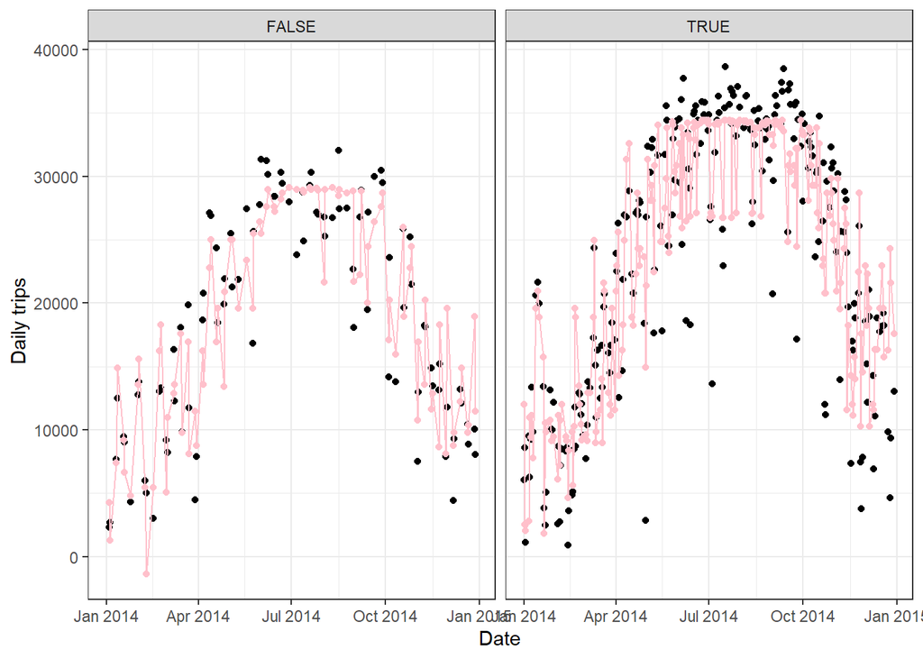

```r
plot_data <- bind_rows(train_trips_per_day, val_trips)

ggplot(plot_data, aes(x = ymd, y = num_trips)) +
  geom_point() +
  geom_line(aes(y = pred), color = "pink") +
  geom_point(aes(y=pred), color = "pink") +
  xlab('Date') +
  ylab('Daily trips') +
  facet_wrap(~isweekday)
```

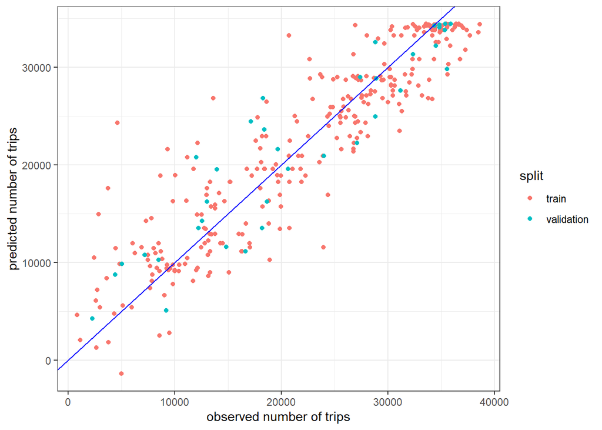

```r
ggplot(plot_data, aes(x=num_trips, y=pred)) +
  geom_point(aes(color=split)) +
  geom_abline(color = "blue")+
  xlab("observed number of trips")+
  ylab("predicted number of trips")
```

> False = weekend and True = weekday

There’s a strange plateau in the model’s predictions at the peak. A good number of observations are above that plateau. The number of rides seem to peak in the summer months with a few exceptions. A very low day in July might just be the 4th of July. It seems the majority of rides are taken during the weekdays - are people using citibikes for their daily commutes? Let’s add in holidays to see how that effects our model.

```r
model4 <- lm(num_trips ~ poly(tmin, 3, raw=T) + isholiday + israining*isweekday, train_trips_per_day)

tidy(model4)
```

```
## # A tibble: 8 x 5
##   term                        estimate std.error statistic  p.value
##   <chr>                          <dbl>     <dbl>     <dbl>    <dbl>
## 1 (Intercept)                    6911.    2481.      2.79  5.70e- 3
## 2 poly(tmin, 3, raw = T)1       -6227.    2013.     -3.09  2.18e- 3
## 3 poly(tmin, 3, raw = T)2        3213.     514.      6.25  1.47e- 9
## 4 poly(tmin, 3, raw = T)3        -267.      40.1    -6.66  1.40e-10
## 5 isholiday                     -8941.    1247.     -7.17  6.39e-12
## 6 israiningTRUE                 -6813.    1065.     -6.40  6.52e-10
## 7 isweekdayTRUE                  5865.     569.     10.3   2.28e-21
## 8 israiningTRUE:isweekdayTRUE    -853.    1238.     -0.688 4.92e- 1
```

```r
glance(model4)
```

```
## # A tibble: 1 x 11
##   r.squared adj.r.squared sigma statistic   p.value    df logLik   AIC   BIC
##       <dbl>         <dbl> <dbl>     <dbl>     <dbl> <int>  <dbl> <dbl> <dbl>
## 1     0.863         0.859 3826.      255. 1.71e-118     8 -2819. 5656. 5689.
## # ... with 2 more variables: deviance <dbl>, df.residual <int>
```

R^2 is .86 so this model explains 86% of the variation in the number of trips per day. Adjusted for the increase in variables, this model explains ~86% of the variation in output (adjusted R^2).

```r
train_trips_per_day %>%
  add_predictions(model4) %>%
  mutate(split = "train") -> train_trips_per_day

#RMSE - training set
train_rmse <-
  sqrt(mean((train_trips_per_day$pred - train_trips_per_day$num_trips)^2))


val_trips %>%
  add_predictions(model4) %>%
  mutate(split="validation") -> val_trips

#RMSE = sqrt(mean((yhat-y)^2)) -> validation set
validate_rmse <-
  sqrt(mean((val_trips$pred - val_trips$num_trips)^2))

  #rmse(model4, val_trips) #same thing as above, the more you know
```

The RMSE for the training set is 3773.3670625 trips. For the validation set, RMSE = 3884.3346081 trips.

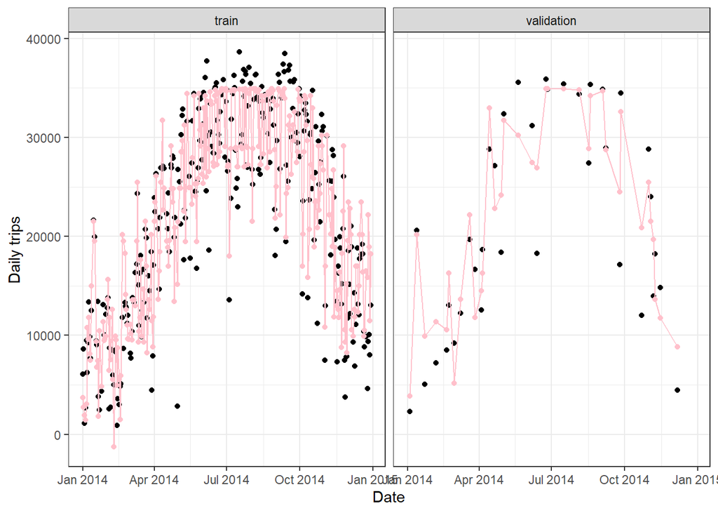

```r
plot_data <- bind_rows(train_trips_per_day, val_trips)

ggplot(plot_data, aes(x = ymd, y = num_trips)) +
  geom_point() +
  geom_line(aes(y = pred), color = "pink") +
  geom_point(aes(y=pred), color = "pink") +
  xlab('Date') +
  ylab('Daily trips') +
  facet_wrap(~split)
```

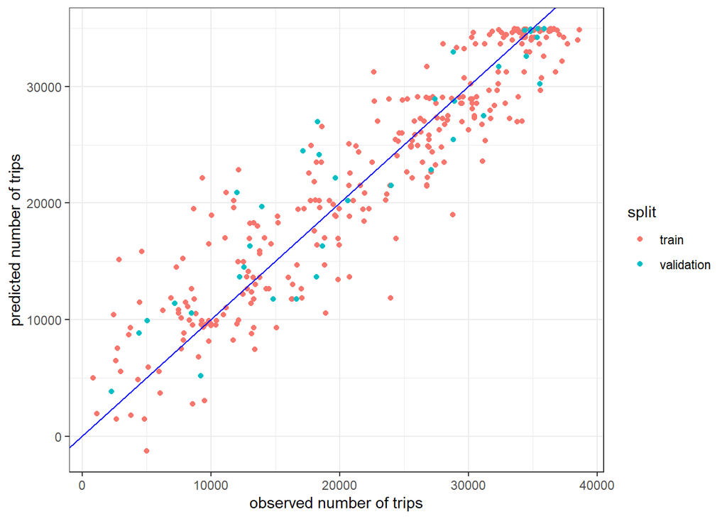

```r
ggplot(plot_data, aes(x=num_trips, y=pred)) +
  geom_point(aes(color=split)) +
  geom_abline(color="blue") +
  xlab("observed number of trips")+
  ylab("predicted number of trips")
```

That weird plateau is still there though it does do better at predicting the odd low periods. The outlier in early July does seem to be the forth of July. That might be useful if you want to know whether there would be an uptick or not on national holidays. It seems to be the case where the majority of people are using citibikes for daily commutes rather than joy rides, however because the coefficient for holidays is negative.

## Choosing a Model

```r
model_list <- list(model1, model2, model3, model4)
train_err <- c()
validate_err <- c()
for(model in model_list){

  #RMSE for training data
  train_err <- c(train_err, sqrt(mean((predict(model, train_trips_per_day) - train_trips_per_day$num_trips)^2)))

  #RMSE for validation data
  validate_err <- c(validate_err, sqrt(mean((predict(model, val_trips) - val_trips$num_trips)^2)))

}

train_err
```

```
## [1] 5520.618 5093.231 4100.957 3773.367
```

```r
validate_err
```

```
## [1] 6191.175 4686.684 3910.130 3884.335
```

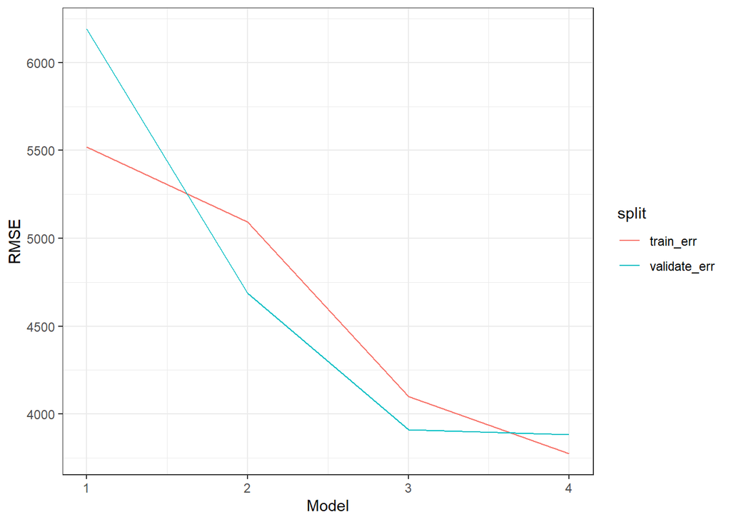

```r
models <- seq(1:length(model_list))

plot_data <-
  data.frame(models, train_err, validate_err) %>%
  gather("split", "error", -models)

plot_data %>%
  ggplot(aes(x=models, y= error, color = split)) +
  geom_line() +
  scale_x_continuous(breaks = models) +
  xlab("Model") +
  ylab("RMSE")
```

I’ll be choosing Model 4 because it has both a small training and validation error - the smallest training error of all my models in fact.

## Saving the best Model

```r
modifiy_trips_data <- function(trips_data){

  left_join(trips_data, holiday, by = c("ymd"="date")) -> trips_data
  trips_data %>%
    mutate(israining = prcp >= 0.1) %>%
    mutate(day_of_week = as.factor(wday(ymd))) %>%
    mutate(isweekday = day_of_week != 1 & day_of_week != 7)%>%
    mutate(isholiday = ifelse(!is.na(holiday), 1, 0))
}


save(modifiy_trips_data, holiday, model4, file='predict_citibike_model.RData')
```

## Final Test

Now we’ll be testing our final model on our untouched test set. Let’s see how Model 4 performs.

```r
test_trips %>%
  add_predictions(model4) %>%
  mutate(split="test") -> test_trips

val_trips %>%
  add_predictions(model4) %>%
  mutate(split="validation") -> val_trips

train_trips_per_day %>%
  add_predictions(model4) %>%
  mutate(split="training") -> train_trips_per_day

test_rmse <-
  sqrt(mean((test_trips$pred - test_trips$num_trips)^2))
```

The RMSE for the testing set is 3883.7613399.

Let’s plot this:

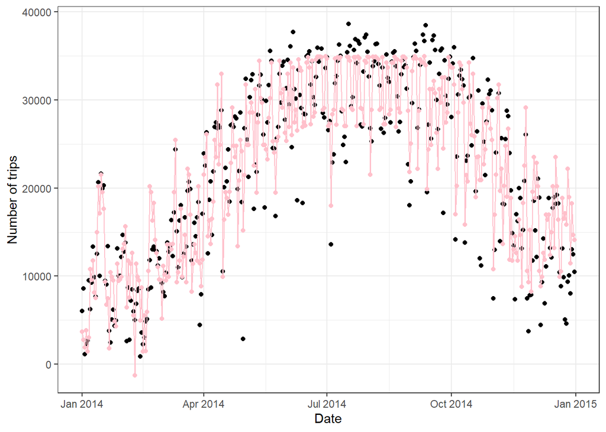

```r
plot_data <- bind_rows(val_trips,test_trips,train_trips_per_day)

ggplot(plot_data, aes(x=ymd, y=num_trips)) +
  geom_point() +
  geom_point(aes(y=pred), color="pink") +
  geom_line(aes(y=pred), color="pink") +
  xlab("Date") +
  ylab("Number of trips")
```

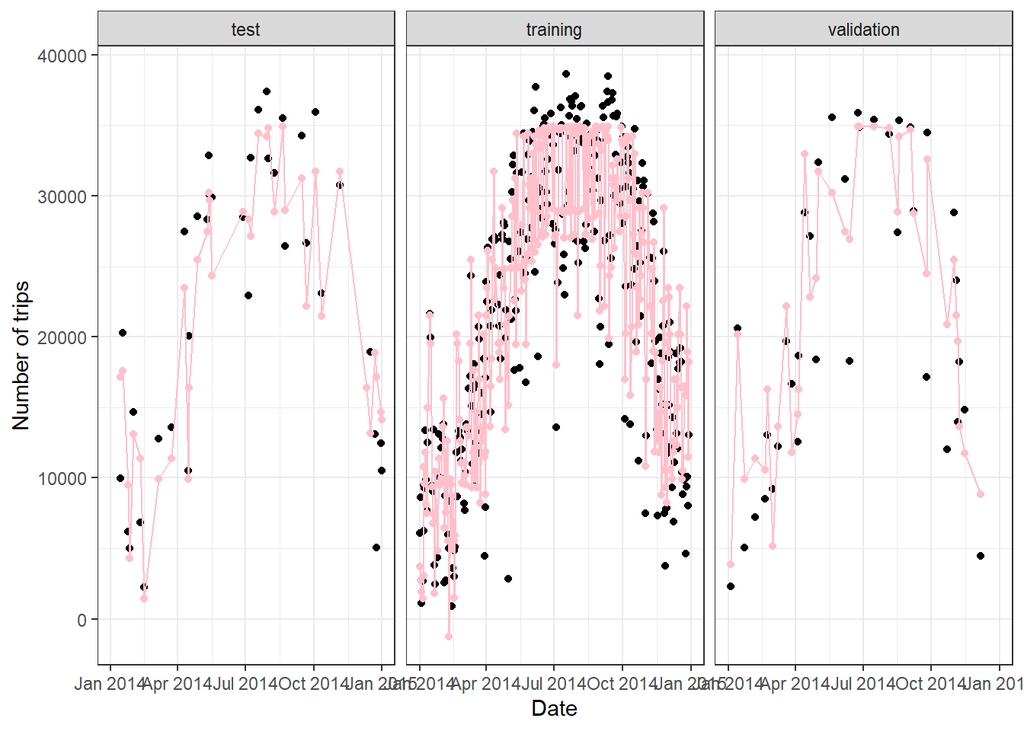

```r
ggplot(plot_data, aes(x=ymd, y=num_trips)) +
  geom_point() +
  geom_point(aes(y=pred), color="pink") +
  geom_line(aes(y=pred), color="pink") +
  xlab("Date") +
  ylab("Number of trips") +
  facet_wrap(~split)
```

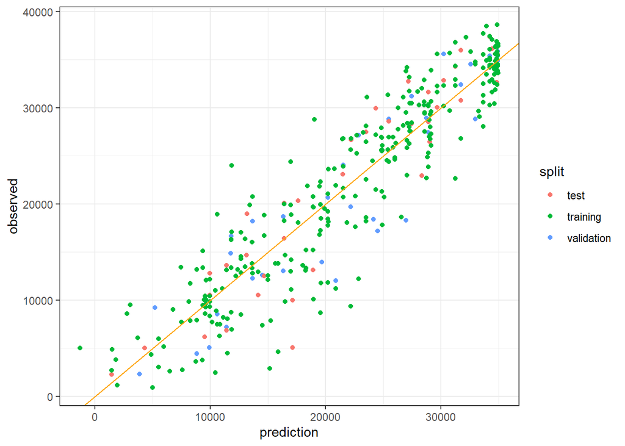

```r
ggplot(plot_data, aes(x=pred, y=num_trips))+
  geom_point(aes(color=split)) +
  geom_abline(color = "orange") +
  xlab("prediction") +
  ylab("observed")
```

## Key results

- The RMSE for the testing set (3883.7613399) is close to the RMSE for the validation set (3884.3346081).
- On the predicted v. observed graph, the points plot in a diagonal, almost 45 degree angle, which is good. It’s close to a 1:1 ratio then.